# Singapore Employment Rate by Education Attainment Across Age & Gender

AAI1001 Team Project Proposal

Author

AAI1001 Team 32

Published

March 5, 2026

# Team Information

| Name | Student ID |
| --- | --- |
| Adheesh | 2500670 |
| Shannon | 2403263 |
| Thiha Thein | 2502266 |
| Jinghong | 2503049 |
| Zafri | 2403108 |

# 1. Introduction and Project Overview

## 1.1 Our Project’s Aim

Singapore’s workforce has undergone a profound educational transformation over the past three decades. University-educated workers now make up the majority of employed residents in the 25–44 age bands, yet there are public debates on whether the labour market has truly absorbed this surge in graduate supply or whether there is a mismatch between qualifications and available jobs.

Our project seeks to answer three interrelated questions using Singapore’s official 2024 Ministry of Manpower data.

**First**, how does educational attainment among *employed* Singaporeans actually vary across age groups, and does the composition differ meaningfully from what population-level data alone suggests?

**Second**, are there meaningful gender gaps in the education–employment relationship that aggregate statistics conceal? The original visualization depicts gender differences but its crowded layout makes it difficult to read.

**Third**, does the employment rate data by gender and age support or challenge the narrative that young, higher educateds workers are having a harder time finding jobs?

Our improved chart aims to answer all three questions in a single visualization by encoding four dimensions simultaneously: age group, sex, employment rate, and education composition. The redesign moves beyond the original chart’s population-count framing to focus on the *employed* resident workforce, revealing where educational capital is concentrated, where gender gaps are widest, and which cohorts show signs of underemployment relative to their qualifications.

## 1.2 Source & Context

The original visualization was published by **FYT Consultants** in a blog post titled *“A Data-Driven Look at Singapore’s Graduate Unemployment Debate”* (September 2025), available at:

> https://www.fytconsultants.com/single-post/a-data-driven-look-at-singapore-s-graduate-unemployment-debate

The underlying data comes from the **Singapore Department of Statistics (SingStat)**, specifically the annual dataset: *Singapore Residents Aged 25 Years and Over by Highest Qualification Attained (HQA), Sex and Age Group*.

## 1.2 Our Chosen Visualization

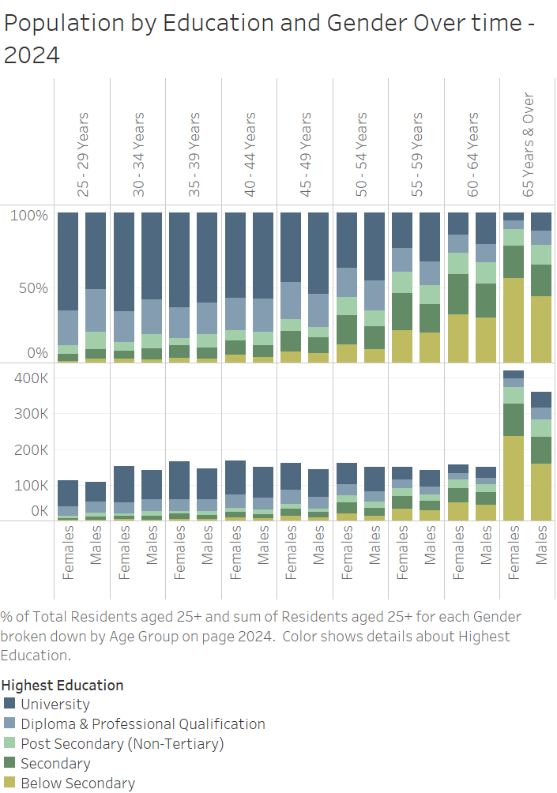

*Figure 1: Original Tableau Visualization — "Population by Education and Gender Over Time – 2024"*  
Source: FYT Consultants / Singapore Department of Statistics

### 1.2.1 Visualization Structure and Design

The visualization selected is a **dual-panel stacked bar chart** titled *“Population by Education and Gender Over Time – 2024”*. The bar chart illustrates Singapore’s resident population aged 25 and above, broken down simultaneously across three dimensions:

1. **Age group** — From ages 25–29 years old through to 65 years old & over
2. **Gender** — Females and Males displayed as adjacent bar pairs within each age group
3. **Highest Educational Attainment** — University, Diploma & Professional Qualification, Post Secondary (Non-Tertiary), Secondary, and Below Secondary

The chart comprises two vertically stacked panels:

- **Top panel (proportional / 100% stacked bars):** Shows the *percentage share* of each education level within a given age–gender group, enabling comparison of educational composition across cohorts.
- **Bottom panel (absolute count bars):** Shows the *actual number of residents* in each age–gender group, providing population size context that the proportional view alone cannot convey.

### 1.2.2 The Story It Tells

The visualization narrates a **generational shift in educational attainment in Singapore**. Several narratives emerge when analysing the stacked bar chart:

**Younger cohorts are markedly more educated.** In the 25–34 age bands, University (dark navy) dominates the top proportional panel, exceeding 50% for both males and females. This proportion of university graduates decreases dramatically as the age group increases.

**Older cohorts show high “Below Secondary” and “Secondary” attainment.** The Below Secondary (yellow) education level becomes prominent in the 60–64 and 65+ groups, reflecting limited access to higher levels of education in the earlier decades.

**The 65+ age group is by far the largest in absolute size.** The bottom panel reveals a striking spike in the 65+ bars compared to all other age groups, reflecting Singapore’s ageing population and contextualising the large “Below Secondary” proportion in that cohort.

**Gender differences in educational attainment are visible but subtle.** In younger cohorts, females and males show comparable university rates; in older cohorts, males sometimes show slightly higher university proportions, reflecting historical gender gaps in access to education.

The bar chart’s dual-panel design is the most distinctive structural feature — it attempts to showcase two stories at once: the composition story (top chart) and the population size story (bottom chart).

# 2. Critical Analysis of Original Visualization

**What this section does:**

We evaluate the original chart’s design choices by identifying what it does well (Strengths) and what limits its analytical value (Weaknesses). These points directly motivate the redesign decisions in Section 3.

### Strengths

What works well

S1

#### Dual-panel design provides complementary context

The most significant design strength is the pairing of a 100% stacked bar (proportional) with an absolute count bar beneath it. A proportional chart alone can be misleading where for example, a cohort with 80% university graduates might represent only a tiny absolute population. Thus, the bottom panel mitigates misinterpretation by revealing the raw counts, making the 65+ spike immediately apparent. This design choice shows awareness of a well-known pitfall in compositional visualization.

S2

#### Consistent colour encoding across education levels

The 5 education levels are mapped to a colour palette, with a legend attached for easy referencing. The dark navy (University) and medium blue (Diploma) occupy the "cool" end of the spectrum, while the yellow-green (Below Secondary) anchors the "warm" end. The colour logic is intuitive where darker/cooler tones are associated with higher attainment.

S3

#### Multi-variable analysis in a single chart

The chart successfully visualizes the intersectional characteristics of age, gender, and education in a single view from a genuinely complex multidimensional dataset.

S4

#### Clear legend and descriptive subtitle

The legend is well-labelled, easy to understand, and directly matches the colour categories used in the bars. The subtitle explains what is being shown in both panels, which is necessary given the chart's complexity.

### Weaknesses

What limits analysis

W1

#### Poor readability from severe x-axis label crowding

The age group labels are printed vertically above the top panel, while the gender labels ("Female" and "Male") are rotated vertically below the bottom panel. With 9 age groups × 2 genders = 18 bar pairs, the labels overlap and are difficult to read at normal resolution. The viewer must invest significant effort tracking which bar belongs to which age group.

W2

#### Visual discontinuity between the two panels

The top and bottom panels are not visually connected by gridlines, reference lines, or shading. The viewer must mentally align bars across the two panels to link a proportional observation with its absolute count. The lack of a linking visual reference weakens the narrative connection that is the chart's core strength.

W3

#### Stacked bars make mid-segment comparison almost impossible

Since "Below Secondary" is the only category anchored to a common baseline (0%), all other education levels float at varying heights. Comparing the "Post Secondary (Non-Tertiary)" share between, say, 35–39 year-old females and 55–59 year-old males requires estimating floating segment boundaries across two different bars which is mentally demanding.

W4

#### The 65+ bar distorts the bottom panel due to its size

The 65+ cohort is so much larger (400K+) that all other bars in the bottom panel appear compressed. The y-axis scale accommodates the maximum value, reducing comparative resolution across all other age groups.

W5

#### No direct value annotations

Neither panel includes data labels or tooltips, as the visualization is a static export. The viewer cannot determine precise percentages or counts without a reference grid.

W6

#### Colour palette has accessibility concerns

The distinction between the light blue (Diploma & Professional Qualification) and light green (Post Secondary Non-Tertiary) segments is subtle and may be difficult for viewers with colour vision deficiencies.

# 3. Proposed Improvements

## 3.1 Enhancement Strategy

Based on the six weaknesses we flagged in Section 2 above, we came up with six improvements that each target a specific problem in the original chart. Rather than doing a general visual refresh, each change has a clear reason behind it. The table below shows exactly which weakness each improvement responds to, and we’ve also noted which of the original chart’s strengths we made sure to carry over.

[output not shown]

✅ Original Strengths Preserved

S2 **One colour per education level, consistently applied.** We kept the same logic of assigning a single colour to each education category throughout. The Wong palette is a swap made for accessibility reasons; the principle of consistent colour coding is preserved, and someone familiar with the original can still familiarise themselves quickly.

S3 **Still a single chart, not a dashboard of panels.** Age group, gender, employment rate, and education breakdown are all readable from one view without needing to open a second panel or cross-reference another figure. We plan to add a new dimension while keeping the single-view approach intact.

## 3.2 Justification for Redesign Approach

Multiple problems identified in Section 2 are not solvable within a static format, so patching the layout would only get us so far. Rebuilding the visualization gives us the room to address those issues properly. Three main reasons drove this decision:

🔄

Interactivity Solves What Static Cannot

The original is a **static image**. The problems with floating segments (W3) and missing value labels (W5) are not design oversights. They are things a static chart simply cannot fix. Making it interactive is the best solution: segment toggles give every category a consistent baseline, and hover tooltips let you read off exact figures and better insights.

📐

Employment Rate Adds the Missing Half

The original only shows education composition where it does not tell us how many of those people are employed. By pulling in **employment rates from MOM Table B1**, we add that labour-market context directly into the same bar. Bar width shows participation, fill shows composition, and both questions get answered at once without needing a second panel.

💡

The Chart Explains Itself

Between the pill labels, the hover tooltip, and the interactive controls, most of what you'd normally need a caption to explain is just visible in the chart itself. A reader can isolate a cohort, toggle education levels, and read off exact figures **without leaving the visualization**. This means the new chart will be more analytically useful as well as professional, giving actionable insights quicker.

**🔍 Why a Butterfly Layout?** Gender comparison is genuinely central to what this dataset is about, and the butterfly format is very intuitive. Males on the left, females on the right and age labels in the middle. You can scan any row horizontally and immediately see the gap between the two sides. As a bonus, it also takes care of the label problem naturally, since the central spine replaces all 18 rotated labels with one clean column.

## 3.3 Proposed Visualization Design

👥Age Group (y-axis, 12 groups)

⚧Gender (left / right wings)

📊Employment Rate % (bar width)

🎓Education Share % (stacked fill colour)

Show segments:

Filter ages:

Male

Age

Female

Employment Rate (%)

Source: MOM Comprehensive Labour Force Survey 2024 · Table B1 (employment rates by age and sex) · Table G4 (education counts by age and sex) · Manpower Research & Statistics Department, Ministry of Manpower, Singapore.

### 3.3.2 Key Design Decisions

- 1

  **Butterfly structure to foreground gender differences**  
  The butterfly layout was selected because it provides the clearest structure for comparing male and female patterns across the same age groups. By mirroring the two sides around a shared central age axis, the chart enables quick horizontal comparison while keeping the layout visually balanced.
- 2

  **Dual encoding within a single chart element**  
  The redesign combines employment rate and education composition within the same horizontal bar. Total bar width encodes employment rate, while internal stacked segments encode qualification share. This allows the visualization to communicate multiple dimensions simultaneously without fragmenting the story into separate views, improving both compactness and interpretive flow.
- 3

  **Interactive controls to support focused exploration**  
  Interactive features were introduced to address the limitations of static presentation. Category toggles, age filtering, and hover tooltips allow the user to isolate subsets, retrieve recalculated values on the fly, and examine patterns in greater detail. These controls improve analytical usability while maintaining a clean overall design.

### 3.3.3 Interaction Features

We built three interactive features into the chart, each one directly addressing something the static original could not do:

🎛️ Segment Toggle

Click any education category in the controls bar to remove it from the chart. The remaining segments automatically recalculate to sum to 100%, so you can compare any subset of education levels like say, just Degree vs Below Secondary, without floating baselines skewing what you see.

🔦 Multi-Select Age Filter

The dropdown lets you pick any combination of age groups to focus on. Rows you deselect disappear from the chart entirely rather than just fading out. This allows users to selectively for exampled, look at the prime working-age bands where the chart redraws around just those rows.

💬 Rich Tooltip on Hover

Hovering over any bar shows the employment rate in percentages to 2 decimal places for that group alongside the full education breakdown. The bar always adds to exactly 100% of that bar. If you've toggled some categories off, the tooltip only shows what's currently visible, so the numbers always match what you're looking at.

# 4. Data Sources & Data Quality

## 4.1 Selected Datasets

Our improved butterfly visualization requires two datasets from the **Ministry of Manpower (MOM) Comprehensive Labour Force Survey 2024**, both sourced from the [MOM Statistics portal](https://stats.mom.gov.sg/Pages/Labour-Force-In-Singapore-2024.aspx). Both are contained within the official published workbooks and are used exclusively for the year **2024**.

Primary Dataset

Table B1 — Resident Employment Rate by Age and Sex, 2014–2024

**File:** LFR2024_SectionB_EmploymentRate.xlsx, Sheet `B1`  
**Publisher:** Manpower Research & Statistics Dept, MOM Singapore  
**Unit:** Per cent (%)  
**Coverage:** 12 age groups × 3 sex categories (Total, Male, Female) × 11 years  
**We use:** Male and Female rows, year 2024 column only

employment rate age group sex 2024

Secondary Dataset

Table G4 — Employed Residents by Highest Qualification, Age and Sex, 2024

**File:** LFR2024_SectionG_MedianAgeDemographicProfile.xlsx, Sheet `G4`  
**Publisher:** Manpower Research & Statistics Dept, MOM Singapore  
**Unit:** Thousands of employed residents  
**Coverage:** 12 age groups × 3 sex categories × 5 education levels  
**We use:** Male and Female rows, all 5 education level columns, 2024 only

education level age group sex count (thousands)

## 4.2 Justification for Dataset Selection

These two datasets were chosen over all other available MOM tables for three specific reasons that directly serve the improved visualization design:

**B1 resolves the 65+ distortion problem (W4).** The original visualization used absolute resident population counts as bar lengths, which caused the 65+ cohort to tower over all other groups. By using employment *rates* from B1 as bar width instead, all 12 age groups are placed on a uniform 0–100% scale. The 65+ and 70+ cohorts naturally produce shorter bars that reflect their lower labour market participation, without any axis distortion.

**G4 provides the education composition for employed residents specifically.** The original chart used *all residents* (employed and non-employed) from SingStat population data. Our redesign focuses the education breakdown on *employed residents only*; the population actually participating in the labour market. This is a more analytically meaningful lens and directly justifies why B1 and G4 must come from the same MOM Labour Force Survey rather than from separate sources.

**Together they enable dual encoding across four dimensions.** No single table alone supports the butterfly chart’s design. Joining B1 (employment rates) with G4 (education composition counts) creates the combined structure needed to encode age, sex, employment rate, and education simultaneously in one visualization.

**Minimum Dimension Requirement** The project requires at least 4 dimensions in the final visualization. The joined dataset encodes **4 dimensions simultaneously**: Age Group (y-axis), Sex (left/right butterfly wings), Employment Rate % (bar width), and Education Level (stacked fill colour). This satisfies the requirement within a single chart without a secondary panel.

## 4.3 Raw Data Structure and Known Challenges

### 4.3.1 B1 Raw Layout

The B1 sheet does not follow a simple rectangular table structure. It uses a **multi-block layout** where each sex group (Total, Male, Female) occupies a separate vertical block of rows, preceded by several metadata rows. The structure is as follows:

[output not shown]

The year 2024 occupies **column 13** (columns 1–2 are labels; column 3 is 2014, incrementing one column per year).

### 4.3.2 G4 Raw Layout

G4 follows the same multi-block convention but has an additional complexity: the **education levels appear as column headers** (not rows), making it a two-dimensional table within each sex block.

[output not shown]

### 4.3.3 Identified Data Quality Challenges

The table below catalogues every known structural issue in the raw files and assigns a severity rating based on how likely it is to cause silent data errors if not handled correctly.

[output not shown]

# 5. Data Engineering Workflow

## 5.1 Planned Data Engineering Pipeline

The pipeline proceeds through five sequential stages. Each stage has a clearly defined input, a set of operations, and a defined output that feeds the next stage.

**Pipeline Principle** Each stage is implemented as a named R function or a clearly commented code block. No stage modifies a previous stage's output in-place. Transformations always produce new objects. This ensures every intermediate state is inspectable and the pipeline can be re-run cleanly from any stage.

1

Ingest Raw Excel Files

Both `.xlsx` workbooks will be loaded using `readxl::read_excel()` with `col_names = FALSE` and no row skipping, so that all rows, including metadata headers, are preserved as data rows. This gives us full control over which rows are treated as headers versus data. The `readxl` package is used specifically because it does not require a Java runtime, unlike the `xlsx` package, making the pipeline more portable across team members' machines. Sheets are specified by name (`"B1"`, `"G4"`) rather than position to guard against sheet order changes in future MOM releases.

readxl::read_excel() col_names = FALSE sheet = "B1" / "G4"

2

Extract 2024 Cross-Section by Gender Block

Using the row offset constants documented in §5.2, each gender block (Male, Female) is extracted from both sheets independently by slicing exactly 12 consecutive rows — one per age group. For B1, column 13 (year 2024) is extracted from each block. For G4, the total column and the five education-level columns are extracted from each block. The result of this stage is four raw tibbles: `emp_male`, `emp_female`, `edu_male`, `edu_female`. A spot-check will confirm that the extracted Male 30–34 employment rate matches the published value of 93.3%.

row slicing [start:(start+11)] column indexing by constant as.numeric() coercion "-" → 0 for G4

3

Reshape to Long (Tidy) Format and Standardise Labels

The four extracted tibbles are combined using `dplyr::bind_rows()` — first `emp_male` and `emp_female` into `emp_2024` (24 rows), then `edu_male` and `edu_female` into `edu_2024` (120 rows). Column names are assigned explicitly as part of the extraction step: `sex`, `age`, `emp_rate` for the employment table; `sex`, `age`, `education`, `count_k`, `total_k` for the education table. Age group and education level columns are converted to ordered `factor` types with levels defined by constants, which guarantees consistent ordering throughout all downstream transformations and chart rendering.

dplyr::bind_rows() factor(..., levels = AGE_LABELS) factor(..., levels = EDU_LABELS) explicit column naming

4

Derive Proportions, Bar Extents, and Butterfly Coordinates

This is the core feature engineering stage. Three new columns are derived. First, **education proportion** (`prop`) is computed as `count_k / total_k` within each age × sex group using `dplyr::group_by()` + `mutate()`. Second, **bar extent** (`bar_extent`) is computed as `emp_rate × prop` — this is the dual-encoding that maps employment rate to bar length and education composition to fill colour simultaneously. Third, **cumulative stacking coordinates** (`xmin2`, `xmax2`) are computed using `cumsum()` within each group, then sign-flipped for the Male wing so that male bars extend leftward (negative x-axis) to create the butterfly layout.

prop = count_k / total_k bar_extent = emp_rate × prop cumsum() for stacking sign flip for male wing

5

Join, Validate, and Export Visualization-Ready Objects

The education long table and the employment rate table are joined on `sex` and `age` using `dplyr::left_join()`, with the education table as the left (primary) side. After joining, four automated validation checks will run: (1) a completeness check that the joined table has exactly 120 rows; (2) a zero-NA check across all visualization-critical columns; (3) a proportion-sum check that all age × sex groups sum within ±2% of 1.0; and (4) a plausibility check that prime working-age (35–54) employment rates exceed 75% for both sexes. Two final objects are exported for the visualization section: `employment_data` (120 rows, the main chart data) and `emp_pills` (24 rows, bar-end label data).

left_join(by = c("sex","age")) completeness assertion NA check proportion-sum check plausibility stopifnot()

## 5.2 Planned Cleaning and Transformation Decisions

Every cleaning choice is listed below with an explicit rationale. This ensures that no transformation is implicit or invisible to future readers of the code.

| # | Issue | Decision | Rationale |
| --- | --- | --- | --- |
| D1 | Metadata header rows above data | Skip using fixed row offset constants; never use `skip =` argument in `read_excel()` | `skip =` silently discards rows; constants are self-documenting and verifiable against the raw sheet |
| D2 | `"-"` string in G4 education counts | Replace with `0` before numeric coercion | Statistically correct — these are suppressed near-zero counts, not missing values; avoids silent `NA` propagation into proportion calculations |
| D3 | Counts published as rounded thousands | Retain in thousands; compute proportions from published totals | Multiplying to raw counts introduces false precision; thousands are sufficient for proportions and the chart does not show absolute counts |
| D4 | Wide format (education as columns) | Reshape to long within the extraction helper function | Long format is required by `ggplot2`’s `geom_rect()` for stacked bar rendering; one row per sex × age × education |
| D5 | No common baseline for education stacking | Pre-compute cumulative `xmin`/`xmax` positions before plotting | Passing raw proportions to `position_stack` in ggplot2 does not support the sign-flip required for the butterfly layout; pre-computation gives full control |
| D6 | Male bars must mirror to negative x-axis | Apply sign flip after cumulative sum: `xmin2 = -xmax`, `xmax2 = -xmin` | Separates the stacking arithmetic cleanly from the butterfly layout logic; the stacking step is sex-agnostic, the flip step handles the visual layout |
| D7 | Unordered factor levels would scramble stacking | Convert `age` and `education` to ordered factors at reshape stage | ggplot2 respects factor levels for ordering; declaring levels once at the reshape stage guarantees consistent order in all downstream objects |

## 5.3 Target Output Schema

Two objects will be passed from the data engineering pipeline to the visualization section. Their schemas are defined here so that the visualization code can be written against a known, stable interface.

employment_data · 120 rows

age factor (12 levels, ordered)

sex factor (Male / Female)

education factor (5 levels, ordered)

emp_rate numeric — employment rate %

prop numeric — education share (0–1)

count_k numeric — employed residents (000s)

total_k numeric — total in age × sex group (000s)

bar_extentnumeric — emp_rate × prop

xmin2 numeric — segment left edge

xmax2 numeric — segment right edge

Primary chart data. One row per age × sex × education combination. `xmin2` and `xmax2` are pre-computed for `geom_rect()`; negative values indicate male wing.

emp_pills · 24 rows

age factor (12 levels, ordered)

sex factor (Male / Female)

emp_rate numeric — employment rate %

bar_end numeric — signed bar-end x position

Label data for employment rate pill annotations at each bar end. One row per age × sex group. `bar_end` is negative for males, positive for females.

**Four Dimensions Confirmed** The `employment_data` schema encodes exactly four dimensions used by the butterfly chart: **age** (y-axis), **sex** (left/right wings via sign of xmin2/xmax2), **emp_rate** (total bar width), and **education** (stacked fill segments). A fifth dimension: **count_k** is available for tooltip display. This satisfies and exceeds the project's 4-dimension minimum requirement.

## 5.4 Illustrative Code Structure

The final pipeline code will follow the structure below. This is not the complete working code — full annotated R code will be provided in the final submission — but it demonstrates the planned function signatures and data flow.

```r
# ── STAGE 1: Ingest ────────────────────────────────────────────
raw_b1 <- read_excel(path_b, sheet = "B1", col_names = FALSE)
raw_g4 <- read_excel(path_g, sheet = "G4", col_names = FALSE)

# ── STAGE 2: Extract 2024 cross-section ────────────────────────
# A named helper function per table type:
extract_emp_rates()    # args: raw sheet, start row, sex label, col index
extract_edu_counts()   # args: raw sheet, start row, sex label, col indices

emp_2024 <- bind_rows(
  extract_emp_rates(raw_b1, B1_MALE_START,   "Male",   B1_COL_2024),
  extract_emp_rates(raw_b1, B1_FEMALE_START, "Female", B1_COL_2024)
)

edu_2024 <- bind_rows(
  extract_edu_counts(raw_g4, G4_MALE_START,   "Male",   ...),
  extract_edu_counts(raw_g4, G4_FEMALE_START, "Female", ...)
)

# ── STAGE 3: Reshape and label ──────────────────────────────────
# Factor levels applied at this stage — once, and only here
edu_2024 <- edu_2024 |>
  mutate(
    age       = factor(age,       levels = AGE_LABELS),
    education = factor(education, levels = EDU_LABELS)
  )

# ── STAGE 4: Feature engineering ───────────────────────────────
edu_2024 <- edu_2024 |>
  group_by(sex, age) |>
  mutate(prop = count_k / total_k)   # education share within group

viz_long <- edu_2024 |>
  left_join(emp_2024, by = c("sex", "age")) |>
  mutate(bar_extent = emp_rate * prop) |>
  group_by(sex, age) |>
  mutate(
    xmax  = cumsum(bar_extent),
    xmin  = xmax - bar_extent,
    xmin2 = if_else(sex == "Male", -xmax, xmin),   # butterfly flip
    xmax2 = if_else(sex == "Male", -xmin, xmax)
  )

# ── STAGE 5: Validate and export ───────────────────────────────
stopifnot(nrow(viz_long) == 120)          # completeness
stopifnot(sum(is.na(viz_long)) == 0)      # no NAs
# ... proportion-sum and plausibility checks

employment_data    <- viz_long |> select(age, sex, education, emp_rate,
                                    prop, count_k, total_k, xmin2, xmax2)
emp_pills    <- ...   # 24-row summary for bar-end labels
```

**Note on Code Status** The pseudocode above illustrates the intended function signatures and data flow. The complete, fully annotated, and tested R implementation, with all validation outputs and intermediate data previews, will be provided in the final Week 13 submission.

## 5.5 Reproducibility Considerations

📁

File Structure

Both `.xlsx` source files will be stored in a `datasets/` subfolder within the project root. File paths will be resolved programmatically relative to the `.qmd` document's own directory using `knitr::current_input()`, so no absolute paths are hard-coded. The pipeline will work on any team member's machine without path editing.

📦

Package Management

All required packages (`readxl`, `dplyr`, `tidyr`, `purrr`, `ggplot2`, `scales`) are loaded at the top of the pipeline section in a single `library()` block. Package versions will be captured and displayed using `sessionInfo()` at the end of the section, enabling any reviewer to verify the exact environment used for the final submission.

🔒

Source File Integrity

MD5 checksums of both source `.xlsx` files will be recorded using `tools::md5sum()` and printed within the document. This allows any reader to verify that the files used to produce the outputs are the original unmodified MOM published files, and provides a clear signal if files are ever accidentally replaced or updated.

📌

Explicit Constants

All row offsets and column indices derived from visual inspection of the raw sheets are stored as named constants (e.g. `B1_MALE_START <- 28L`, `G4_COL_TOTAL <- 3L`) in a single dedicated code block. No magic numbers appear inside extraction functions. If MOM updates the file layout, only the constants block needs updating — the extraction logic is unaffected.

✅

Built-in Assertions

Four automated validation checks (`stopifnot()` assertions) will be embedded directly in the pipeline: row count completeness, zero-NA check, proportion-sum tolerance, and prime-age plausibility. If any check fails, the document will halt with an informative error message rather than silently producing incorrect output. This makes data errors impossible to overlook during rendering.

🔄

No External Dependencies

The pipeline requires no internet connection, no database connections, and no API calls. All data is loaded from local files bundled with the project. The Quarto document can be rendered offline on any machine with R and the listed packages installed. There are no stochastic operations, so no random seed is needed — the output is fully deterministic.

# 6. Data Analysis Plan

## 6.1 What This Analysis Is For

Our butterfly chart already shows the patterns visually, but this section adds a few simple calculations so we can state the key findings with clear numbers.

- **(A1)** Which age groups show the largest **male–female employment rate gap**
- **(A2)** How the **Secondary school** qualification share differs across female age groups
- **(A3)** Whether age groups with higher **Degree** share tend to have higher **employment rates**

🧾 Basic & clear

We will only use descriptive metrics (differences, shares, simple indices).

🔍 Supports the chart

Each calculation corresponds to what we can see in our new butterfly chart.

📊 Produces outputs

Each method produces either a table or a simple plot.

## 6.2 Measures We Will Compute

Employment gap measures (B1, 2024)

Employment rateemp_rate (%, by age × sex)

Gender employment gapGap = Male − Female (pp)

This quantifies the left/right bar-width differences you see in the butterfly chart.

Education composition measures (G4, 2024)

Education shareshare = count_k / total_k

Secondary share focusshare_secondary (by age × sex)

Education concentrationHHI = Σ(share²)

Share supports the stacked colours; HHI tells whether a cohort is dominated by one level or more mixed.

## 6.3 Planned Analyses

### A1 — Gender Employment Gap by Age (where is the gap biggest?)

**Question:** In 2024, which age group show the largest difference in employment rate between males and females?

**Metric (percentage points):** - **Gap(age) = emp_rate_male(age) − emp_rate_female(age)**

**Output:** A ranked table + a dot plot (or bar chart) of gaps across age bands.

**Insight:** We expect the employment gaps to be small in early working ages but widen at later ages, indicating differing labour force participation patterns by sex.

### A2 — “Secondary School Qualification” Share Among Employed Females

**Question:** In 2024, for employed females, how does the share of **Secondary school** qualification change across age groups?

**Metric:** - **SecondaryShare_female(age) = SecondaryCount_female(age) ÷ TotalEmployed_female(age)**

**Output:** A single line/dot plot: age bands on y-axis, secondary share on x-axis (female only).  
(We can also add male as a comparison line.)

**Insight:** In 2024, we expect Secondary school qualification share among employed females to be lower in younger age groups but to rise strongly in older age groups, because diploma/degree pathways were less accessible for older cohorts and Secondary was more common as a highest qualification during that period.

### A3 — Education vs Employment (do more degree-heavy cohorts also have higher employment rates?)

**Question:** Across 2024 age groups, is higher **Degree qualification share** associated with higher **employment rate**?

**Metrics:** - **DegreeShare(age, sex) = DegreeCount ÷ TotalEmployed** - Compare with **emp_rate(age, sex)**

**Output:** A scatter plot (per sex):  
x = Degree share, y = employment rate, points labelled by age group.

**Insight:** In 2024, age groups with a higher Degree share generally also show higher employment rates, especially in the prime working ages (25–54). However, the relationship weakens after 55 because employment rates fall sharply due to labour-force exit/retirement, even if some Degree holders remain. This would suggest education composition aligns with employment participation, but age effects are the dominant driver at older ages.

## 6.4 Summary: What We Produce (2024)

| ID | Question Answered (2024) | Output | Supports Which Insight | Data Needed |
| --- | --- | --- | --- | --- |
| A1 | Where is the gender employment gap largest? | Gap plot + table | Bar-width differences (employment rate) | B1 (2024 only) |
| A2 | How does female Secondary school qualification share differ by age group? | Line / dot plot | Education composition shift (Secondary) | G4 (2024 only) |
| A3 | Is degree share linked to employment rate across age groups? | Scatter plot | Dual-encoding logic (width × fill) | B1 + G4 (2024 only) |

# 7. Planned Work Distribution

| Team Member | Primary Tasks | Est. Hours |
| --- | --- | --- |
| Adheesh | Proposed improvements with detailed justifications | ~12 hrs |
| Shannon | Data Engineering Workflow & Appendix | ~12 hrs |
| Thiha Thein Kevin | Data sources + Planned data analysis | ~10 hrs |
| Jinghong | Project Story & Visualization Analysis | ~12 hrs |
| Zafri | Planned Data Analysis | ~10 hrs |
| All Members | Content Moderation & Document Formatting | ~8 hrs each |

# 8. References

## 8.1 Article Source

- D. Yuen, “A Data-Driven Look at Singapore’s ‘Graduate Unemployment’ Debate,” FYT Consultants, Sep. 17, 2025. https://www.fytconsultants.com/single-post/a-data-driven-look-at-singapore-s-graduate-unemployment-debate

## 8.2 Data Sources

- Singapore Department of Statistics, 2026, “Singapore Residents Aged 25 Years & Over By Highest Qualification Attained (HQA), Sex And Age Group, Annual,” data.gov.sg. https://data.gov.sg/datasets/d_1020b8ee03923042a8ab8e26eef58093/view
- Ministry of Manpower, “Labour Force in Singapore 2024,” Mom.gov.sg, 2024. https://stats.mom.gov.sg/Pages/Labour-Force-In-Singapore-2024.aspx

## 8.3 Design Reference

- B. Wong, “Points of View: Color Blindness,” Nature Methods, vol.8, no. 6, pp. 441–441, May 2011, doi: https://doi.org/10.1038/nmeth.1618

# 9. Appendix: Data Dictionary

The two tidy objects produced by the data engineering pipeline are documented below. Every column used by the visualization or tooltip layer is defined here with its source, unit, valid range, and role in the chart.

## A.1 `employment_data` — Primary Visualization Table

120 rows · one row per **age group × sex × education level** combination.

| Column | R Type | Source | Unit / Range | Role in Chart |
| --- | --- | --- | --- | --- |
| `age` | `factor` (12 levels) | B1 & G4 row labels | Age band e.g. `"25-29"` | Y-axis position |
| `sex` | `factor` (2 levels) | B1 & G4 block headers | `"Male"` or `"Female"` | Left / right butterfly wing |
| `education` | `factor` (5 levels) | G4 column headers | See level definitions below | Stacked fill colour |
| `emp_rate` | `numeric` | B1, Sheet B1, col 13 | Percent, 0–100 | Total bar width |
| `prop` | `numeric` | Derived: `count_k / total_k` | Proportion, 0–1 | Each segment’s share of bar width |
| `count_k` | `numeric` | G4, education columns | Thousands of employed residents | Tooltip display |
| `total_k` | `numeric` | G4, total column | Thousands of employed residents | Proportion denominator |
| `bar_extent` | `numeric` | Derived: `emp_rate × prop` | Percent-points, 0–100 | Width of each stacked segment |
| `xmin2` | `numeric` | Derived: cumulative stacking + sign flip | Signed percent, −100 to +100 | Left edge of segment (`geom_rect`) |
| `xmax2` | `numeric` | Derived: cumulative stacking + sign flip | Signed percent, −100 to +100 | Right edge of segment (`geom_rect`) |

**Education level factor definitions** (in stacking order, bottom to top):

| Level | Label | Description |
| --- | --- | --- |
| 1 | Below Secondary | No secondary qualification attained |
| 2 | Secondary | GCE N/O-Level or equivalent |
| 3 | Post-Secondary (Non-Tertiary) | ITE, vocational certificates |
| 4 | Diploma & Prof Qual | Polytechnic diploma or professional qualification |
| 5 | Degree | Bachelor’s degree or above |

**Sign convention for `xmin2` / `xmax2`:** negative values place the segment on the Male (left) wing; positive values place it on the Female (right) wing. A value of `0` is the central age-group spine.

## A.2 `emp_pills` — Bar-End Label Table

24 rows · one row per **age group × sex** combination.

| Column | R Type | Source | Unit / Range | Role in Chart |
| --- | --- | --- | --- | --- |
| `age` | `factor` (12 levels) | Derived from `employment_data` | Age band | Y-axis alignment |
| `sex` | `factor` (2 levels) | Derived from `employment_data` | `"Male"` or `"Female"` | Determines label side |
| `emp_rate` | `numeric` | B1, Sheet B1 | Percent, 0–100 | Label text displayed in pill |
| `bar_end` | `numeric` | Derived: `−emp_rate` (Male) / `+emp_rate` (Female) | Signed percent | X-position of pill label anchor |

**Note:** `emp_pills` is a summary of `employment_data` with education collapsed. It drives only the pill annotation layer (`geom_text`) and is not used for any bar geometry.